# Prise de main avec Python

```python
# Prise de main avec Python
```

```python
## Introduction
```

Python est un langage de programmation populaire trés utilisé en apprentissage automatique et l'analyse des données.

Dans ce tutoriel rapide, nous présenterons l'essentiel sur les types de base de Python, numpy, Pandas et Matplotlib

Une documentation plus complète est disponible ici : https://python.land/python-tutorial

# Installation de Python sur votre ordinateur :

## Installez Python via Anaconda

Anaconda est une distribution scientifique de Python : En installant Anaconda, Python ainsi que d'autres packages sont aussi installés

Téléchargez la distribution Anaconda qui correspond à votre système d’exploitation, en Python version 3 : https://www.anaconda.com/download

[figure not shown]

```python
# Lancez Anaconda
Sous Windows, lancez Anaconda Navigator depuis votre liste de programmes
```

[figure not shown]

```python
# Lancez Jupyter notebook
```

[figure not shown]

[figure not shown]

# Créer un notebook Jupyter

[figure not shown]

[figure not shown]

## Charger un jupyther notebook

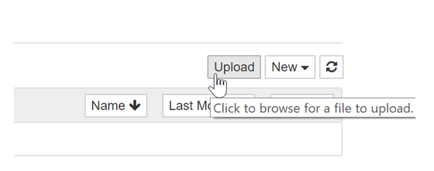

### Alternative

Les notebook peuvent aussi être exécutés sur Colab. Aucune installation ou configuration de votre machine est requise dans ce cas

https://colab.research.google.com/

[figure not shown]

## 1- Python

### Versions de Python

```python
import sys
print("Version de Python")
print (sys.version)
```

```
Version de Python
3.7.4 (default, Aug  9 2019, 18:34:13) [MSC v.1915 64 bit (AMD64)]
```

```python
help(sys)          # obtenir un help sur une fonction
```

[output not shown]

[output cut: 297 more lines]

[output not shown]

```python
### Les commentaires
```

```python
# commentaire sur une ligne

def fonc():

    """
    commentaires sur plusieurs lignes

    """
    return 0
```

## Types des variables

```python
#les variables sont dynamiquement typées
x = 1 #integer
x = 3.5 #float
y= True  # boolean
print((x + 1)-3)
y=(x *2)**2
print(x )
print(y)
x *= x+1
print(x)
```

```
1.5
3.5
49.0
15.75
```

## affichage des types des variables

```python
x=25
print(type(x))
y=2.5
print(type(y))
y=False
print(type(y))
```

```
<class 'int'>
<class 'float'>
<class 'bool'>
```

## Chaînes de caractères

```python
hello = 'hello'
world = "world"
```

```python
Chaine = hello + ' ' + world  # concaténation de chaînes de caractères
print(Chaine)
```

```
hello world
```

### Chaîne formatées (commencent par f):

```python
print(f"La variable hw vaut {Chaine}")
PI=3.14159265359
print(f"La variable {PI} arrondie à deux chiffres après la virgule= {PI:.2f}")
```

```
La variable hw vaut hello world
La variable 3.14159265359 arrondie à deux chiffres après la virgule= 3.14
```

```python
### Opérations sur les chaînes de caractères:
```

```python
s = "hello"
print (len(s))    # len:longeur de la chaine s
print(s.capitalize())
print(s.upper())
print(s.rjust(10))
print(s.center(10))
```

```
5
Hello
HELLO
     hello
  hello
```

### les Listes

Les listes Python sont l'équivalent des tableaux mais elle peuvent contenir des variables ayant des types différents.

```python
liste = [3, True, "Hello",2.6]    # Création d'une liste
print(type(liste))
print(liste[2])  # les indices sont numérotés à partir de 0
print(liste[-1])     # on accede à la fin de la liste)
print("la liste contient",len(liste),"elements")    # on affiche le nombre d'éléments de la liste
```

```
<class 'list'>
Hello
2.6
la liste contient 4 elements
```

```python
liste.append(False) # append permet d'ajouter un élément à la fin de la liste
print(liste)
liste.insert(0,30) # insert permet d'ajouter un élément à une position de la liste
print(liste)
```

[output not shown]

```python
x = liste.pop()     # pop enlève et retourne le dernier élément de la liste
print(x)
print(liste)
```

```
False
[30, 3, True, 'Hello']
```

```python
liste = liste.pop()
print(liste)
```

```
Hello
```

```python
xs = [10,3,2.6]
xs.sort()
print(xs)
xs.extend([7,8,9])
print(xs)
```

```
[2.6, 3, 10]
[2.6, 3, 10, 7, 8, 9]
```

```python
##### Slicing  ( acceder à des sous listes de la liste originale)
```

```python
tab=range(5)
print(tab)

liste = list(tab)   # list permet de créer une liste   (voir help(list))
print(liste)
print(liste[1:3])    # afficher les éléments de la liste entre les indices 1 (inclus) et 3 (exclu)
print(liste[3:])     # dafficher tous les éléments de la liste à partir de l'indice 3
print(liste[:3])     # du début jusque l'indice 3 exclu (3 élements)
print(liste)         # toute la liste
print(liste[:])      # toute la liste

print(liste[:-1])    # du début jusque l'avant-dernier élément
print(len(liste))
print(liste[:len(liste)-1])    #  jusque l'avant-dernier élément

liste[2:4] = [8, 9]  # remplace une sous-liste
print(liste)
```

```
range(0, 5)
[0, 1, 2, 3, 4]
[1, 2]
[3, 4]
[0, 1, 2]
[0, 1, 2, 3, 4]
[0, 1, 2, 3, 4]
[0, 1, 2, 3]
5
[0, 1, 2, 3]
[0, 1, 8, 9, 4]
```

On peut itérer sur les éléments d'une liste:

```python
animals = ['cat', 'dog']
for animal in animals:
    print(animal)
```

```
cat
dog
```

```python
liste=list(range(5))
print(liste)
```

```
[0, 1, 2, 3, 4]
```

```python
liste*3    #  dupliquer la liste 3 fois
```

```
[0, 1, 2, 3, 4, 0, 1, 2, 3, 4, 0, 1, 2, 3, 4]
```

```python
liste+3    #  erreur
```

```
---------------------------------------------------------------------------
TypeError                                 Traceback (most recent call last)
<ipython-input-7-66caa027ad7c> in <module>
----> 1 liste+3

TypeError: can only concatenate list (not "int") to list
```

```python
liste+list(range(3))  # concacternation
```

```
[0, 1, 2, 3, 4, 0, 1, 2]
```

### Les Fonctions

Les fonctions Python sont définies par le mot-clé `def`

```python
def somme_deux_nombres(x,y):
    return(x+y)

somme_deux_nombres(10,2)
```

```
12
```

### Structure conditionnelle

```python
def comparaison(x,y):
    if x > y:
        return 'x est supérieur à y'
    elif x < y:
        return 'x est inférieur à y'
    else:
        return 'x et y sont égaux'

comparaison (0,3)   # appel de la fonction
```

```
'x est inférieur à y'
```

```python
def parite(x):
    if x % 2==0:
        return 'x est paire'
    else:
        return 'x est impaire'

for x in [5, 10, 0,-2]:
    print(parite(x)) # appel de la fonction pour les 4 chiffres
```

```
x est impaire
x est paire
x est paire
x est paire
```

### Structure itérative

```python
for i in range(4):
    print(i)

print ('......')
for i in range(1,8,2):  #  affiche les nombres de 1 à 8 par pas=2
    print(i)
```

```
0
1
2
3
......
1
3
5
7
```

## --------------------------------------------------------------------------------------------------------------------------

## 2-Numpy

### Numpy permet de définir le type array qui est trés utilsé pour le calcul scientifique avec python.

[documentation numpy](https://numpy.org/)

### Pour utiliser numpy, il faut d'abord importer le package `numpy`

```python
import numpy as np
```

```python
a = np.array([1, 2, 3])  # crée un array de dimension 1
print(type(a))
print(a.shape)   # a.shape donne la dimension du tableau
print(a[0], a[1], a[2])
a[0] = 5                 # change l'élément d'indice 0
print(a)
```

```
<class 'numpy.ndarray'>
(3,)
1 2 3
[5 2 3]
```

```python
a=a.reshape(a.shape[0],1)   # reshape change le vecteur ligne a en un vecteur colonne
print(a)
print(a.shape)
type(a)
```

[output not shown]

```
numpy.ndarray
```

```python
a = np.array([1, 2, 3])  # crée un array de dimension 1
a=a.reshape(a.shape[0],-1)   # une autre manière pour changer le vecteur ligne a en un vecteur colonne
print(a)
print(a.shape)
```

```
[[1]
 [2]
 [3]]
(3, 1)
```

```python
print(b[0, 0], b[0, 1], b[1, 0])
```

[output not shown]

```python
a = np.zeros((2,3))  #  crée une matrice de zeros de dimension 2*3
print(a)
```

```
[[0. 0. 0.]
 [0. 0. 0.]]
```

```python
b = np.ones((2,5))    #  crée une matrice de 1 de dimension 2*5
print(b)
```

```
[[1. 1. 1. 1. 1.]
 [1. 1. 1. 1. 1.]]
```

```python
d = np.eye(2)
print(d)
```

```
[[1. 0.]
 [0. 1.]]
```

```python
### ajouter une colonne à un tableau
```

```python
Y = np.array([4.,  6.,  2.])
print(Y)
Y.shape
```

```
[4. 6. 2.]
```

```
(3,)
```

```python
A=np.ones(1)
print(A.shape)
Y = np.concatenate([np.ones(1),Y])
print(Y)
```

```
(1,)
[1. 4. 6. 2.]
```

```python
### Ajouter  une nouvelle colonne à une matrice
```

```python
X=np.array([[1,2,3],[4,5,6]])
print(X)
y=np.ones(X.shape[0])
print(y)
print('concatenation de y et X')
X=np.c_[y,X]
print(X)
```

```
[[1 2 3]
 [4 5 6]]
[1. 1.]
concatenation de y et X
[[1. 1. 2. 3.]
 [1. 4. 5. 6.]]
```

### Transformer une liste en un tableau

```python
myList=[1,True,False]
print(myList)
print("myList est de type;",type(myList))
```

```
[1, True, False]
myList est de type; <class 'list'>
```

```python
my_array = np.array(myList)
print("my_array est de type",type(my_array))
print(my_array)
```

```
my_array est de type <class 'numpy.ndarray'>
[1 1 0]
```

```python
 ## Slicing
 ###Il y a plusieurs manières de parcourir les tableaux Numpy.
```

```python
mat = np.array([[1,2,3,4], [5,6,7,8], [9,10,11,12]])
print(mat)

b = mat[:2, 1:3]
print(b)
print(mat[::-1])
```

```
[[ 1  2  3  4]
 [ 5  6  7  8]
 [ 9 10 11 12]]
[[2 3]
 [6 7]]
[[ 9 10 11 12]
 [ 5  6  7  8]
 [ 1  2  3  4]]
```

```python
tab1 = mat[2, :]
tab2 = mat[1:2, :]

print(tab1, tab1.shape)
print(tab2, tab2.shape)
```

```
[ 9 10 11 12] (4,)
[[5 6 7 8]] (1, 4)
```

### Calcul matriciel avec Numpy

```python
x = np.array([[1,2],[3,4]])
y = np.array([[5,6],[7,8]])

print(np.add(x, y))   # ou bien x+y
```

```
[[ 6  8]
 [10 12]]
```

```python
print(np.subtract(x, y))   # ou bien x-y
```

```
[[-4 -4]
 [-4 -4]]
```

```python
print(np.multiply(x, y)) # ou bien x*y
```

```
[[ 5 12]
 [21 32]]
```

```python
print(np.divide(x, y))  #ou bien x/y
```

[output not shown]

```python
print(np.sqrt(x))
```

```
[[1.         1.41421356]
 [1.73205081 2.        ]]
```

```python
x = np.array([[1,2],[3,4]])
w = np.array([11, 12])
print(np.dot(x, w))
```

```
[35 81]
```

```python
v = np.array([9,10])
print(np.dot(x, v))
```

```
[29 67]
```

```python
x = np.array([[1,2],[3,4]])
y = np.array([[5,6],[7,8]])

print(np.dot(x, y))
```

```
[[19 22]
 [43 50]]
```

```python
x = np.array([[1,2],[3,4]])

print(x)
print(np.sum(x))
print(np.sum(x, axis=0))
print(np.sum(x, axis=1))
print(np.transpose(x)) # Transposée  ou bien x.T
print(np.min(x))  # Valeur min  ou bien x.min()
print(x.max())  # ou bien np.max(x)
print(np.mean(x,axis=0))
```

```
[[1 2]
 [3 4]]
10
[4 6]
[3 7]
[[1 3]
 [2 4]]
1
4
[2. 3.]
```

```python
print(x)
np.power(x,2)
```

```
[[1 2]
 [3 4]]
```

```
array([[ 1,  4],
       [ 9, 16]], dtype=int32)
```

## 3-Pandas

```python
Pandas est une librairie python pour extraire, préparer, éventuellement analyser, des données
Les données sont sauvegardées dans des tableaux de données avec des étiquettes de variables (colonnes) et d'individus (lignes).
ces tableaux sont appelés DataFrames
on peut lire et écrire ces dataframes à partir ou vers un fichier tabulé.
```

```python
# importer la librairie pandas
import pandas as pd
```

```python
df = pd.read_csv('E:\ML\dataset\iris_csv.csv')  # lire les données dans un dataframe  df


df.head()     #  affiche les 5 premieres lignes du df
```

|  | sepallength | sepalwidth | petallength | petalwidth | class |
| --- | --- | --- | --- | --- | --- |
| 0 | 5.1 | 3.5 | 1.4 | 0.2 | Iris-setosa |
| 1 | 4.9 | 3.0 | 1.4 | 0.2 | Iris-setosa |
| 2 | 4.7 | 3.2 | 1.3 | 0.2 | Iris-setosa |
| 3 | 4.6 | 3.1 | 1.5 | 0.2 | Iris-setosa |
| 4 | 5.0 | 3.6 | 1.4 | 0.2 | Iris-setosa |

```python
type(df)
```

```
pandas.core.frame.DataFrame
```

```python
df.sample(10)    #  afficher 10 lignes choises aléatoirement du dataframe
```

|  | sepallength | sepalwidth | petallength | petalwidth | class |
| --- | --- | --- | --- | --- | --- |
| 78 | 6.0 | 2.9 | 4.5 | 1.5 | Iris-versicolor |
| 132 | 6.4 | 2.8 | 5.6 | 2.2 | Iris-virginica |
| 130 | 7.4 | 2.8 | 6.1 | 1.9 | Iris-virginica |
| 42 | 4.4 | 3.2 | 1.3 | 0.2 | Iris-setosa |
| 59 | 5.2 | 2.7 | 3.9 | 1.4 | Iris-versicolor |
| 139 | 6.9 | 3.1 | 5.4 | 2.1 | Iris-virginica |
| 100 | 6.3 | 3.3 | 6.0 | 2.5 | Iris-virginica |
| 40 | 5.0 | 3.5 | 1.3 | 0.3 | Iris-setosa |
| 23 | 5.1 | 3.3 | 1.7 | 0.5 | Iris-setosa |
| 80 | 5.5 | 2.4 | 3.8 | 1.1 | Iris-versicolor |

```python
df.columns   # decrire les colonnes
```

```
Index(['sepallength', 'sepalwidth', 'petallength', 'petalwidth', 'class'], dtype='object')
```

```python
df.shape    # dimension
```

```
(150, 5)
```

```python
df.describe()
```

|  | sepallength | sepalwidth | petallength | petalwidth |
| --- | --- | --- | --- | --- |
| count | 150.000000 | 150.000000 | 150.000000 | 150.000000 |
| mean | 5.843333 | 3.054000 | 3.758667 | 1.198667 |
| std | 0.828066 | 0.433594 | 1.764420 | 0.763161 |
| min | 4.300000 | 2.000000 | 1.000000 | 0.100000 |
| 25% | 5.100000 | 2.800000 | 1.600000 | 0.300000 |
| 50% | 5.800000 | 3.000000 | 4.350000 | 1.300000 |
| 75% | 6.400000 | 3.300000 | 5.100000 | 1.800000 |
| max | 7.900000 | 4.400000 | 6.900000 | 2.500000 |

```python
# slice

print(df[5:8])    # afficher les lignes de 5 à 7.

sliced_df=df[5:8]
print(sliced_df)
```

```
   sepallength  sepalwidth  petallength  petalwidth        class
5          5.4         3.9          1.7         0.4  Iris-setosa
6          4.6         3.4          1.4         0.3  Iris-setosa
7          5.0         3.4          1.5         0.2  Iris-setosa
   sepallength  sepalwidth  petallength  petalwidth        class
5          5.4         3.9          1.7         0.4  Iris-setosa
6          4.6         3.4          1.4         0.3  Iris-setosa
7          5.0         3.4          1.5         0.2  Iris-setosa
```

```python
 #sélectionner certaines colonnes du dataframe
data=df[["sepallength","class"]]
print(data.head())
```

```
   sepallength        class
0          5.1  Iris-setosa
1          4.9  Iris-setosa
2          4.7  Iris-setosa
3          4.6  Iris-setosa
4          5.0  Iris-setosa
```

```python
data=df.loc[:,["sepallength","class"]]    # ou bien
extraire les données avec loc selon les noms des colonnes
print(data)
```

```
     sepallength           class
0            5.1     Iris-setosa
1            4.9     Iris-setosa
2            4.7     Iris-setosa
3            4.6     Iris-setosa
4            5.0     Iris-setosa
..           ...             ...
145          6.7  Iris-virginica
146          6.3  Iris-virginica
147          6.5  Iris-virginica
148          6.2  Iris-virginica
149          5.9  Iris-virginica

[150 rows x 2 columns]
```

```python
data=df.iloc[:,[0,4]]                  #ou bien  extraire les données selon les numéros des colonnes
print(data)
```

```
     sepallength           class
0            5.1     Iris-setosa
1            4.9     Iris-setosa
2            4.7     Iris-setosa
3            4.6     Iris-setosa
4            5.0     Iris-setosa
..           ...             ...
145          6.7  Iris-virginica
146          6.3  Iris-virginica
147          6.5  Iris-virginica
148          6.2  Iris-virginica
149          5.9  Iris-virginica

[150 rows x 2 columns]
```

```python
data=df.iloc[2]
data
```

```
sepallength            4.7
sepalwidth             3.2
petallength            1.3
petalwidth             0.2
class          Iris-setosa
Name: 2, dtype: object
```

```python
data=df.loc[df["class"] == "Iris-setosa"]   #filtrer les données
```

```python
 # partager les 5 premieres données en deux vecteurs
X = df.iloc[:5, :1].values    # X contient les 5 premieres lignes avec seulement la premiere colonne
y = df.iloc[:5, -1].values    # y contient les 5 premieres lignes avec seulement la derniere colonne
print(X)
print("le type de X est:",type(X), X.shape)
print(y)
print("le type de y est :",type(y),y.shape)
```

```
[[5.1]
 [4.9]
 [4.7]
 [4.6]
 [5. ]]
le type de X est: <class 'numpy.ndarray'> (5, 1)
['Iris-setosa' 'Iris-setosa' 'Iris-setosa' 'Iris-setosa' 'Iris-setosa']
le type de y est : <class 'numpy.ndarray'> (5,)
```

```python
 df['class'].value_counts()
```

```
Iris-setosa        50
Iris-versicolor    50
Iris-virginica     50
Name: class, dtype: int64
```

```python
sum_data = df["sepallength"].sum()
mean_data = df["sepallength"].mean()
median_data = df["sepallength"].median()

print("Sum:",sum_data, "\nMean:", mean_data, "\nMedian:",median_data)
```

```
Sum: 876.5
Mean: 5.843333333333335
Median: 5.8
```

```python
### convertir les labels en des numéros
```

```python
# Import LabelEncoder
from sklearn import preprocessing
#creating labelEncoder
le = preprocessing.LabelEncoder()
# Converting string labels into numbers.

df['class'] = le.fit_transform(df['class'])
df.sample(10)
```

|  | sepallength | sepalwidth | petallength | petalwidth | class |
| --- | --- | --- | --- | --- | --- |
| 9 | 4.9 | 3.1 | 1.5 | 0.1 | 0 |
| 96 | 5.7 | 2.9 | 4.2 | 1.3 | 1 |
| 61 | 5.9 | 3.0 | 4.2 | 1.5 | 1 |
| 10 | 5.4 | 3.7 | 1.5 | 0.2 | 0 |
| 100 | 6.3 | 3.3 | 6.0 | 2.5 | 2 |
| 33 | 5.5 | 4.2 | 1.4 | 0.2 | 0 |
| 79 | 5.7 | 2.6 | 3.5 | 1.0 | 1 |
| 93 | 5.0 | 2.3 | 3.3 | 1.0 | 1 |
| 89 | 5.5 | 2.5 | 4.0 | 1.3 | 1 |
| 75 | 6.6 | 3.0 | 4.4 | 1.4 | 1 |

```python
# verfier qu'il n'existe pas des valeurs nulles dans le dataset
df.isnull().sum()
```

```
sepallength    0
sepalwidth     0
petallength    0
petalwidth     0
class          0
dtype: int64
```

## 4. Matplotlib

```python
Matplotlib est une bibliothèque graphique pour tracer des graphes
```

```python
import matplotlib.pyplot as plt
```

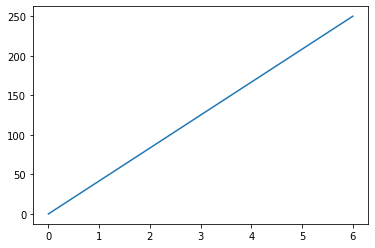

```python
X = np.array([0, 6])
Y = np.array([0, 250])

plt.plot(X, Y)
plt.show()
```

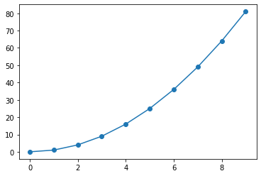

```python
X=np.array(range(10))

Y = np.power(X,2)


plt.plot(X, Y,marker="o")
plt.show()
```

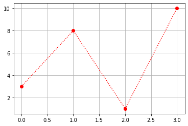

```python
ypoints = np.array([3, 8, 1, 10])

plt.plot(ypoints, 'o:r')     #marker|line|colorù
plt.grid(True)
plt.show()
```

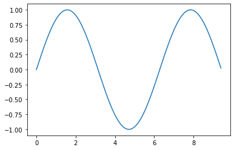

```python
x = np.arange(0, 3 * np.pi, 0.1)
y = np.sin(x)

plt.figure()
plt.plot(x, y);
```

```python
afficher plusieurs graphiques dans la même figure avec `subplot`:
```

```
[ 0.          0.09983342  0.19866933  0.29552021  0.38941834  0.47942554
  0.56464247  0.64421769  0.71735609  0.78332691  0.84147098  0.89120736
  0.93203909  0.96355819  0.98544973  0.99749499  0.9995736   0.99166481
  0.97384763  0.94630009  0.90929743  0.86320937  0.8084964   0.74570521
  0.67546318  0.59847214  0.51550137  0.42737988  0.33498815  0.23924933
  0.14112001  0.04158066 -0.05837414 -0.15774569 -0.2555411  -0.35078323
 -0.44252044 -0.52983614 -0.61185789 -0.68776616 -0.7568025  -0.81827711
 -0.87157577 -0.91616594 -0.95160207 -0.97753012 -0.993691   -0.99992326
 -0.99616461 -0.98245261 -0.95892427 -0.92581468 -0.88345466 -0.83226744
 -0.77276449 -0.70554033 -0.63126664 -0.55068554 -0.46460218 -0.37387666
 -0.2794155  -0.1821625  -0.0830894   0.0168139   0.1165492   0.21511999
  0.31154136  0.40484992  0.49411335  0.57843976  0.6569866   0.72896904
  0.79366786  0.85043662  0.8987081   0.93799998  0.96791967  0.98816823
  0.99854335  0.99894134  0.98935825  0.96988981  0.94073056  0.90217183
  0.85459891  0.79848711  0.7343971   0.66296923  0.58491719  0.50102086
  0.41211849  0.31909836  0.22288991  0.12445442  0.02477543]
[ 2.   2.1  2.2  2.3  2.4  2.5  2.6  2.7  2.8  2.9  3.   3.1  3.2  3.3
  3.4  3.5  3.6  3.7  3.8  3.9  4.   4.1  4.2  4.3  4.4  4.5  4.6  4.7
  4.8  4.9  5.   5.1  5.2  5.3  5.4  5.5  5.6  5.7  5.8  5.9  6.   6.1
  6.2  6.3  6.4  6.5  6.6  6.7  6.8  6.9  7.   7.1  7.2  7.3  7.4  7.5
  7.6  7.7  7.8  7.9  8.   8.1  8.2  8.3  8.4  8.5  8.6  8.7  8.8  8.9
  9.   9.1  9.2  9.3  9.4  9.5  9.6  9.7  9.8  9.9 10.  10.1 10.2 10.3
 10.4 10.5 10.6 10.7 10.8 10.9 11.  11.1 11.2 11.3 11.4]
```

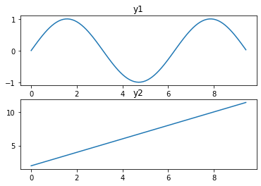

```python
X = np.arange(0, 3 * np.pi, 0.1)
y1 =np.sin(X)
y2=X+2
print(y1)
print(y2)
plt.figure()

plt.subplot(2, 1, 1)


plt.plot(X, y1)
plt.title('y1')


plt.subplot(2, 1, 2)
plt.plot(X, y2)
plt.title('y2')


plt.show();
```

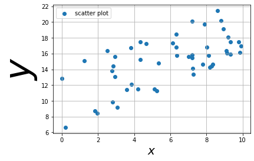

```python
size = 50
m = 1
b = 10
e = 4
x = 10*np.random.rand(size)
y = m*x + b + (2*e)*np.random.rand(size)-e
plt.grid(True)

plt.scatter(x, y)
plt.ylabel(r'$y$', fontsize = 60)
plt.xlabel(r'$x$', fontsize = 20)
plt.legend(['scatter plot'])
```

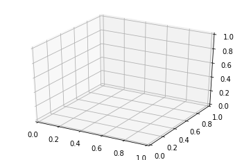

```python
from mpl_toolkits import mplot3d
fig = plt.figure()
ax = plt.axes(projection='3d')
```

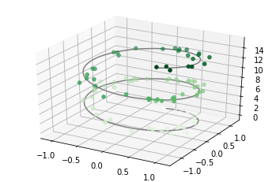

```python
from mpl_toolkits import mplot3d
ax = plt.axes(projection='3d')

# Data for a three-dimensional line
zline = np.linspace(0, 15, 1000)
xline = np.sin(zline)
yline = np.cos(zline)
ax.plot3D(xline, yline, zline, 'gray')

# Data for three-dimensional scattered points
zdata = 15 * np.random.random(100)
xdata = np.sin(zdata) + 0.1 * np.random.randn(100)
ydata = np.cos(zdata) + 0.1 * np.random.randn(100)
ax.scatter3D(xdata, ydata, zdata, c=zdata, cmap='Greens');
```

Plus d'informations: [documentation matplotlib.pyplot](https://matplotlib.org/2.0.2/api/pyplot_api.html)